# svmodt: An R Package for Linear SVM-Based Oblique Decision Trees

Aneesh Agarwal (Monash University) , Jack Jewson (Monash University) , Erik Sverdrup (Monash University)  
2025-10-29

## 1 Introduction

Introduction

Decision trees remain among the most widely adopted machine learning algorithms due to their interpretability, ease of use, and ability to handle both categorical and numerical data without extensive preprocessing. Classical algorithms such as CART (Breiman et al. 1984) and C4.5 (Quinlan 2014) employ axis-aligned (univariate) splits that partition the feature space along coordinate axes. While this approach ensures transparency in decision-making, it often necessitates deep trees with many nodes to approximate diagonal or curved decision boundaries, leading to increased model complexity and potential overfitting (Pagallo and Haussler 1990). Fig 1

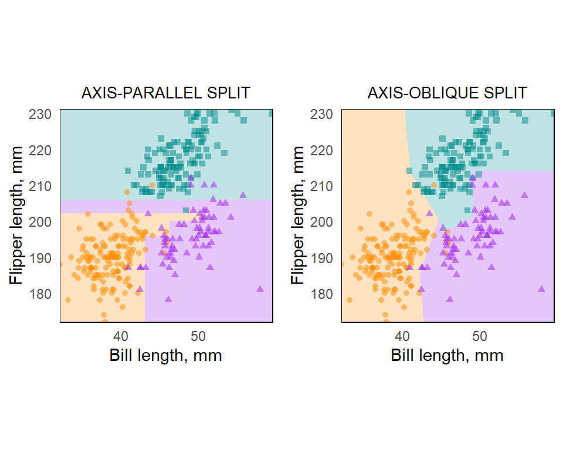

Figure 1: Axis Parallel Split vs Oblique Split on Palmerpenguins dataset

Oblique decision trees, which allow splits based on linear combinations of features, address this limitation by enabling more flexible partitioning of the feature space. A single oblique split such as $w_1x_1 + w_2x_2 < \theta$ can replace multiple axis-aligned splits ($x_1 < \theta$) needed to approximate the same boundary. Despite their representational advantages, oblique trees have seen limited adoption in practice, partly due to the computational complexity of finding optimal multivariate splits (Brodley and Utgoff 1995) and the scarcity of accessible, well-documented software implementations, particularly in R.

Support Vector Machines (SVMs), introduced by Cortes and Vapnik (1995), provide a principled approach to finding optimal separating hyperplanes by maximizing the margin between classes. The integration of SVMs into decision tree structures was pioneered by Bennett and Blue (1998), who proposed fitting an SVM at each internal node to determine multivariate splits. This hybrid approach combines the interpretability of trees with the robust margin-based optimization of SVMs. Subsequent work has extended this concept through various algorithmic refinements (Takahashi and Abe 2002; Bala and Agrawal 2011; Ganaie et al. 2022), yet fully-featured, accessible implementations remain scarce in the R ecosystem.

Research Objectives

This paper addresses three key limitations in existing decision tree implementations:

First, we tackle the computational inefficiency of traditional two-phase pruning approaches. Classical methods like CART grow a maximal tree before applying cost-complexity pruning via cross-validation (Breiman et al. 1984). This approach wastes computation on branches that are ultimately removed and requires tuning multiple hyper-parameters. We propose integrated cost-complexity pruning, where pruning decisions are made in real-time during tree construction. We propose integrated cost-complexity pruning where pruning decisions are made in real-time during tree construction to maintain theoretical optimality.

Second, we address the lack of flexible oblique tree implementations in R. While Python’s STree (Montañana et al. 2021) and specialized packages exist, R practitioners lack access to SVM-based oblique trees with modern features such as dynamic feature selection, node-specific class weighting, and built-in visualization tools. Our SVMODT (SVM-based Oblique Decision Tree) implementation fills this gap with a comprehensive, well-documented package designed for both research and practical applications.

Third, we introduce novel algorithmic enhancements including: (1) dynamic feature selection strategies that adjust the number of features considered based on tree depth; (2) feature diversity through penalization, which discourages repeated use of the same features across ancestor-descendant paths; and (3) node-specific class weighting that adapts to local class distributions during recursive splitting, providing more effective handling of imbalanced data sets than global weighting schemes.

Organization

## 2 Acknowledgements

The authors would like to thank Professor **Natalia Da Silva** and Professor **Dianne Helen Cook** for their constructive discussions and valuable insights regarding oblique decision trees and their implementations in R. The authors also acknowledges the use of OpenAI’s GPT-5 model (ChatGPT) for editorial assistance and technical writing support during the preparation of this manuscript. All conceptual development, analysis, data processing, coding, and interpretation of results were performed independently by the author. The AI tool was used solely to refine language clarity, improve structure, and ensure stylistic consistency in the documentation.

M. Bala and R. Agrawal. Optimal decision tree based multi-class support vector machine. *Informatica*, 35(2): 2011.

K. P. Bennett and J. A. Blue. A support vector machine approach to decision trees. In *1998 IEEE international joint conference on neural networks proceedings. IEEE world congress on computational intelligence (cat. no.98CH36227)*, pages. 2396–2401 vol3 1998. DOI 10.1109/IJCNN.1998.687237.

L. Breiman, J. H. Friedman, R. A. Olshen and C. J. Stone. *Classification and regression trees.* Wadsworth, 1984. URL http://lyle.smu.edu/~mhd/8331f06/cart.pdf.

C. E. Brodley and P. E. Utgoff. Multivariate decision trees. *Machine Learning*, 19: 45–77, 1995. URL https://api.semanticscholar.org/CorpusID:16836572.

C. Cortes and V. Vapnik. Support-vector networks. *Machine learning*, 20(3): 273–297, 1995.

M. A. Ganaie, M. Tanveer, P. N. Suganthan and V. Snasel. Oblique and rotation double random forest. *Neural Networks*, 153: 496–517, 2022. URL https://www.sciencedirect.com/science/article/pii/S0893608022002258.

R. Montañana, J. A. Gámez and J. M. Puerta. STree: A single multi-class oblique decision tree based on support vector machines. 54–64, 2021.

G. Pagallo and D. Haussler. Boolean feature discovery in empirical learning. *Machine Learning*, 5: 71–99, 1990. URL https://api.semanticscholar.org/CorpusID:5661437.

J. R. Quinlan. *C4. 5: Programs for machine learning.* Elsevier, 2014.

F. Takahashi and S. Abe. Decision-tree-based multiclass support vector machines. In *Proceedings of the 9th International Conference on Neural Information Processing*, pages. 1418–1422 vol3 2002. ISBN 981-04-7524-1. DOI 10.1109/ICONIP.2002.1202854.